# Inverse Problem: Forward Model

September 2, 2015

## We'd like to simulate here

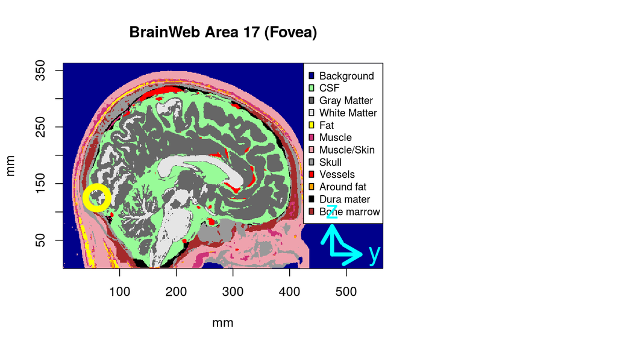

## What Per does here

**ferret visual cortex**

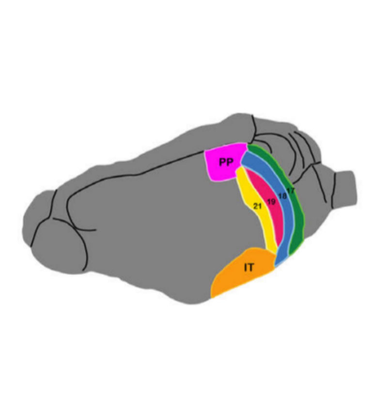

## We need

- A labeled phantom
- Optical and acoustic properties of tissue and dye
- Likely concentration of dye in brain
- NIR and US simulators
- Neural activity simulator

## We have

- A labeled phantom: BrainWeb from [McGill](http://brainweb.bic.mni.mcgill.ca/cgi/brainweb1?alias=subject04_crisp&download=1)
- Optical and acoustic properties of tissue and dye (??)
- Dye concentration estimate based on: ICG, FUS delivery (??)
- NIR simulator(s)
  - Monte Carlo photon-level
  - Deterministic voxel-level (being tested)
  - RTE solver ([Abhinav Jha](http://www.ncbi.nlm.nih.gov/pmc/articles/PMC3963433/))
- Prototype code for US and neural activity

## The phantom

- The BrainWeb discrete anatomical model of normal brain
- Each voxel is labeled by its majority tissue
- 1 mm<sup>3</sup> voxels
- DL Collins, et. al., [Design and Construction of a Realistic Digital Brain Phantom](http://www.bic.mni.mcgill.ca/users/louis/papers/phantom/)

## Optical properties of tissue (??)

- Sparse and variable
- Steven L Jacques, Optical properties of biological tissues: a review, 2013, [Phys. Med. Biol. 58 R37](http://iopscience.iop.org/0031-9155/58/11/R37)
- [Inverse problem repository at github](http://brain-initiative.github.io/know_brainR/Rmds/jacques.html)

## Optical properties of tissue: Example

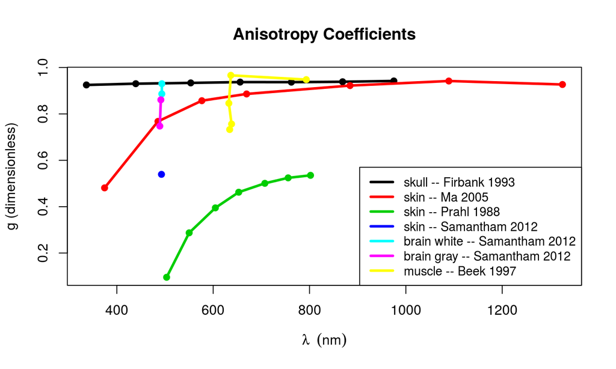

## Optical properties of dye (??)

**Peaks are real, spectral shapes are guesswork**

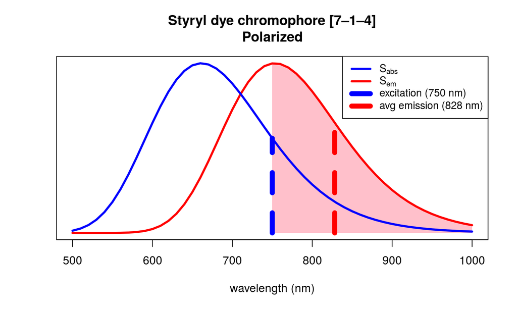

## Acoustic properties of tissue (??)

- Sparse
- [National Physical Laboratories of the UK](http://www.kayelaby.npl.co.uk/general_physics/2_4/2_4_6.html) by the National Physical Laboratories of the UK
- [Inverse problem repository at github](http://brain-initiative.github.io/know_brainR/Rmds/acoustic_properties.html)

## Acoustic properties of tissue: Examples

| Medium | \(\rho \: (kg/m^3)\) | \(c \: (m/s)\) | \(\alpha \: (dB/(m \cdot MHz))\) | Proxy |
| --- | --- | --- | --- | --- |
| CSF | 1000 | 1480 | 0.0022 |  |
| Gray Matter | 1030-1041 | 1562 | 0.5-1.66 |  |
| White Matter | 1030-1041 | 1562 | 1.2-2.5 |  |
| Muscle/Skin | 1090-1130 | 1635-1678 | 1.87-2.87 | muscle/epidermis averages |
| Skull | 1610 | 2190-3289 | 11-20 |  |
| Bone marrow | 1014-1021 | 1513-1566 | 0.7-1.57 | muscle/fat/blood averages |

## Acoustic properties of dye (??)

- Excited dye loses energy through vibrational relaxation,
- which transfers energy to surrounding tissue.
- If transferred energy dissipates as pressure wave
- then a 10% photoacoustic effect?

## 10% photoacoustic effect?

\(E\left(\lambda_{em}\right) = \frac{\int_{\lambda_{abs}}^{\infty}\lambda S_{em}(\lambda)d\lambda}{\int_{\lambda_{abs}}^{\infty}S_{em}(\lambda)d\lambda} = 828\), \(\:\:\:\:\:\frac{750}{828} \approx 0.90\)

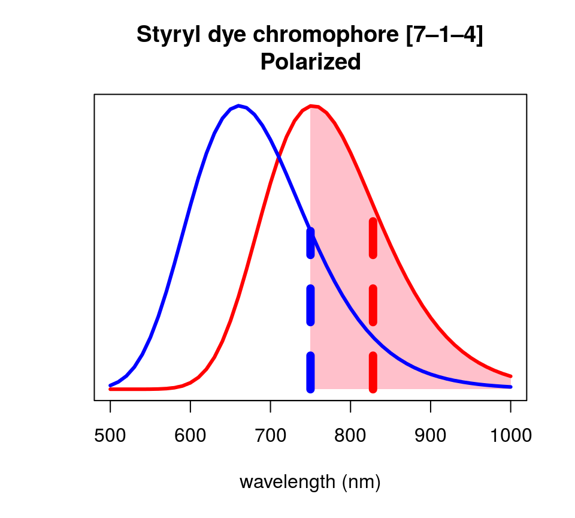

## Likely concentration of dye in brain

- Used [indocyanine green](http://brain-initiative.github.io/know_brainR/Rmds/safe_dose.html) as proxy.
- Estimated safe dose is 0.6 mg IV for 70 kg human.
- Five percent, 0.0387\(\mu\)mol, might end up in the brain.
- For 1 \(\mu\)M, distribute over 38700 mm<sup>3</sup> of brain volume.
- Foveal area of phantom primary visual cortex is ~300 mm<sup>3</sup>.
- Focused ultrasound has 10 mm<sup>3</sup> "grain of rice" resolution.
- **Will dye bind irreversibly to cell membranes?**
- **To what extent will unbound dye diffuse?**

## NIR Simulation: photon level

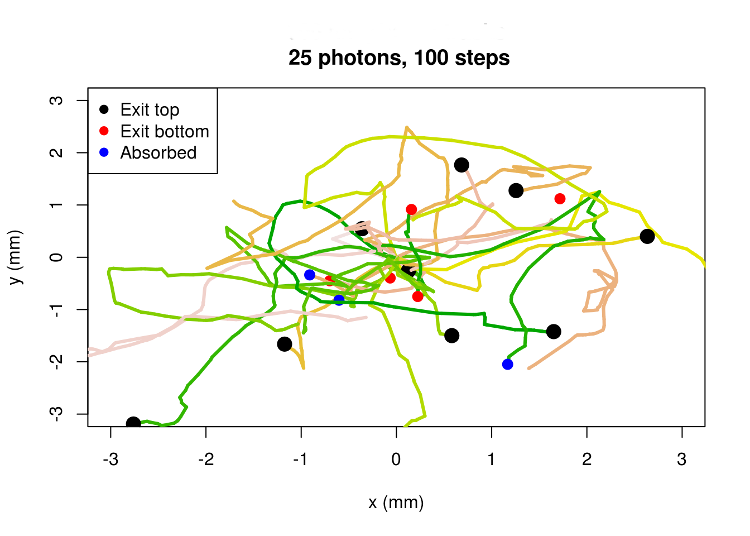

## NIR Simulation: photon level

- Monte Carlo
- Anisotropic scattering using Henyey-Greenstein angle distributions
- Absorption
- Reflection/Refraction using Snell
- About 1/500 nanosecond per step
- Exhibits 1 mm optical diffusion limit, as does real tissue

## NIR Simulation: bulk properties

Probabilities of each of 3 events per voxel per step are estimated from photon-level simulations.

| Tissue | P(scatter) | P(absorb) | P(reflect/refract) |
| --- | --- | --- | --- |
| Muscle/Skin | 0.95 | 0.0071 | 0.044 |
| Skull | 0.84 | 0.0011 | 0.16 |
| CSF | 0.0045 | 0.0035 | 0.992 |
| Gray Matter | 0.859 | 0.0021 | 0.139 |
| White Matter | 0.956 | 0.00041 | 0.0441 |

## NIR Simulation: bulk propeties

As are probabilities of crossing tissue boundaries once encountered.

| . | CSF | Gray Matter | White Matter |
| --- | --- | --- | --- |
| CSF | 1.0 | 0.96 | 0.95 |
| Gray Matter | 0.84 | 1.0 | 0.97 |
| White Matter | 0.81 | 0.90 | 1.0 |

## NIR Simulation: voxel-level

- Use probabilites from photon-level as proportions
- Per step, calculate
  - proportion absorbed in each voxel
  - proportion crossing between voxels
  - add and subtract appropriate

## NIR Simulation: voxel-level

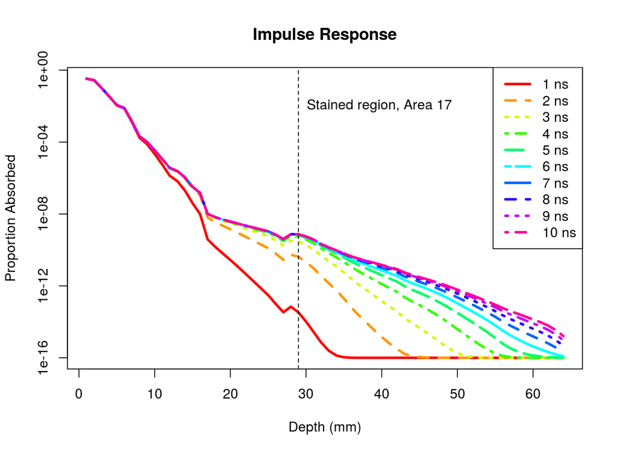

## NIR Simulation: caveats

Currently, voxel-level simulation

- Indicates **deeper** NIR penetration than is consistent with
  - X. D. Li, et. al., [Fluorescent diffuse photon density waves in homogeneous and heterogeneous turbid media](https://scholar.google.com/scholar?cluster=14532648682143150618&hl=en&as_sdt=0,21)
- Indicates **shallower** NIR penetration than is consistent with:
  - L. Nie, et. al., [Photoacoustic tomography through a whole adult human skull with a photon recycler](http://www.ncbi.nlm.nih.gov/pmc/articles/PMC3487537/)
  - L. Wang and L. Gao [Photoacoustic microscopy and computed tomography: from bench to bedside](http://www.ncbi.nlm.nih.gov/pmc/articles/PMC4102891/)

Analysis and testing are in progress.

## Simulation of neural activity

Quoting the BRAIN initiative proposal

> We may use the recent observation that the VSD signal at x can be lumped as a generalized single compartment representing the dominant neurons in **the volume.**

\[-C_M \frac{\partial V(x,t)}{\partial t} = g_E(x,t)(V(x,t)-E_E) \\+ g_I(x,t)(V(x,t)-E_I) \\ + g_L(x,t)(V(x,t)-E_L)\]

> where \(g_E(x,t)\) and \(g_I(x,t)\) are generalized excitatory and inhibitory conductances indicating the total neuronal input to the area located at x.

## Simulation of neural activity: scale?

- What volume?
- [Petersen et. al.](http://www.jneurosci.org/content/23/4/1298.long) verified the claim in live rat barrel cortex volumes of ~0.04 mm<sup>3</sup>.
- Which would mean 25 compartments per 1 mm<sup>3</sup> BrainWeb voxel.
- Does the claim scale up?
- Short answer: Yes.
  - Mean response to 25 stimuli approximates single response to mean stimulus
  - 98% average correlation (100 trials.)

## Simulation of neural activity:

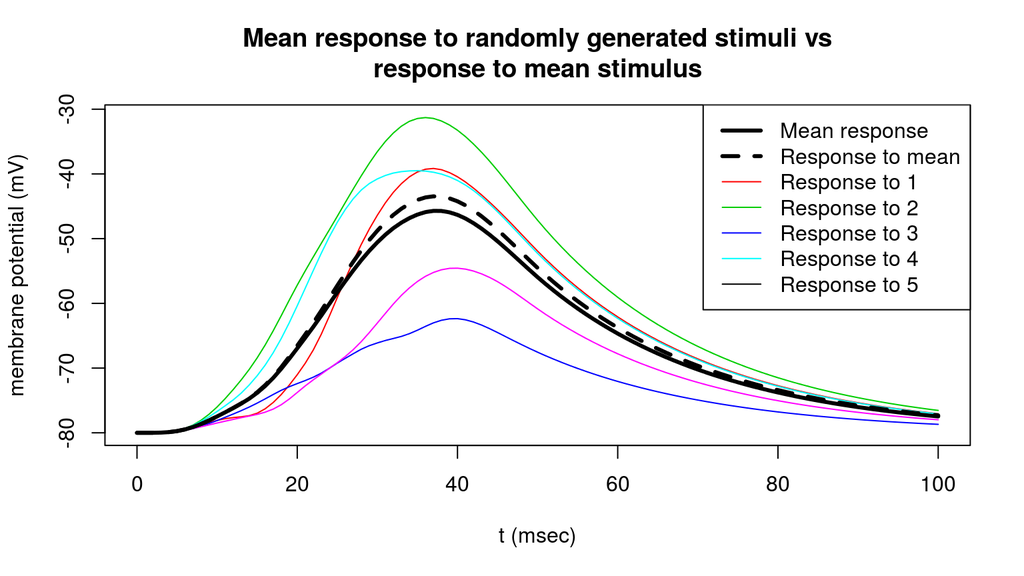

## Loose ends

- Ultrasound: prototype code suggests
  - Inverse r<sup>2</sup> (spherical wave) losses will predominate.
  - US direction will not be affected by scattering.
  - Refraction at skull is likely to cause apparent source displacement.
  - US spatial resolution would be much better than diffuse NIR.
  - Signal strength???

## Loose ends

- Linearity:
  - NIR propagation is linear. Simulation results can be superimposed.
  - Absorption varies linearly with stain concentration in 1-5 \(\mu\)M range.
  - Absorption varies linearly with voltage and (probably) with pH.
- Two-photon excitation should be considered.
  - Requires two absorptions at \(2\lambda_{abs}\) rather than 1 at \(\lambda_{abs}\)
  - Scattering & absorption properties better at \(2\lambda_{abs}\)
  - Focus is better: quadratic rather than linear

## Technologies: free and open source

- The [R statistical programming language](https://www.r-project.org/)
  - 7000+ curated packages
  - [12<sup>th</sup> most popular language](http://www.r-bloggers.com/r-leaps-to-12-in-tiobe-language-popularity-index/) and climbing.
- The [Rstudio](https://www.rstudio.com/) [IDE](https://github.com/rstudio/rstudio/)
- The [git distributed version control system](https://git-scm.com/)
  - Developed by Linus Torvalds for the Linux kernel.
  - Entire development history recorded and recoverable.
  - Code integrity protected by secure hash (SHA1)

## Technologies: free as in beer

- [Github](https://github.com) online git server
  - Reigning collaborative development site
  - Supports [websites](http://brain-initiative.github.io/know_brainR/)
  - Supports issue forums and wikis
  - Emails project members when changes occur
  - Small fees for private repositories